# Question 1

```r
# Produce a matrix of random numbers drawn from N(0,1)
set.seed(8242) # last 4 digits of my phone number
M1 <- matrix(rnorm(10000*1001),nrow=10000, ncol = 1001)

# Check if the above yields the exact same (“random”) dataset
M1[1:10]
```

```
##  [1] -0.22793486 -1.26447103  1.57990688  0.08350937 -0.51386386  0.10945371
##  [7] -0.67473218  0.78655014  1.36147096  0.06123462
```

```r
M1[9990:10000]
```

```
##  [1]  0.56302533 -0.93821782 -0.15840531 -1.02803124 -0.38648826 -0.08664699
##  [7] -0.53301360  0.23277023  0.78880543 -1.03596902 -1.43895572
```

# Question 2

```r
# Treat the first column as “y” and the remaining 1000 columns as x’s
y <- M1[,1]
x <- M1[,2:1001]
```

# Question 3,4

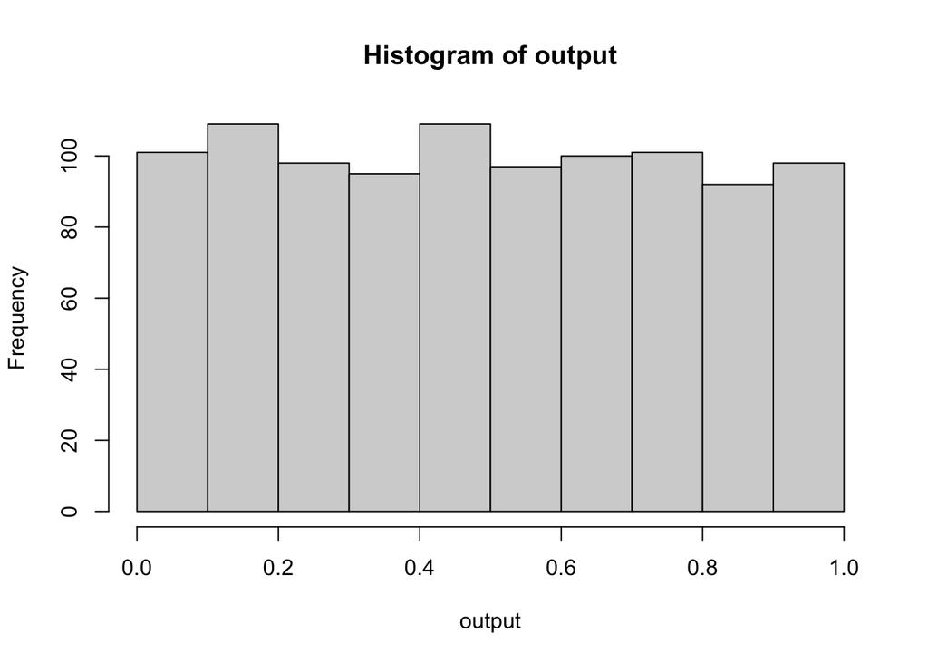

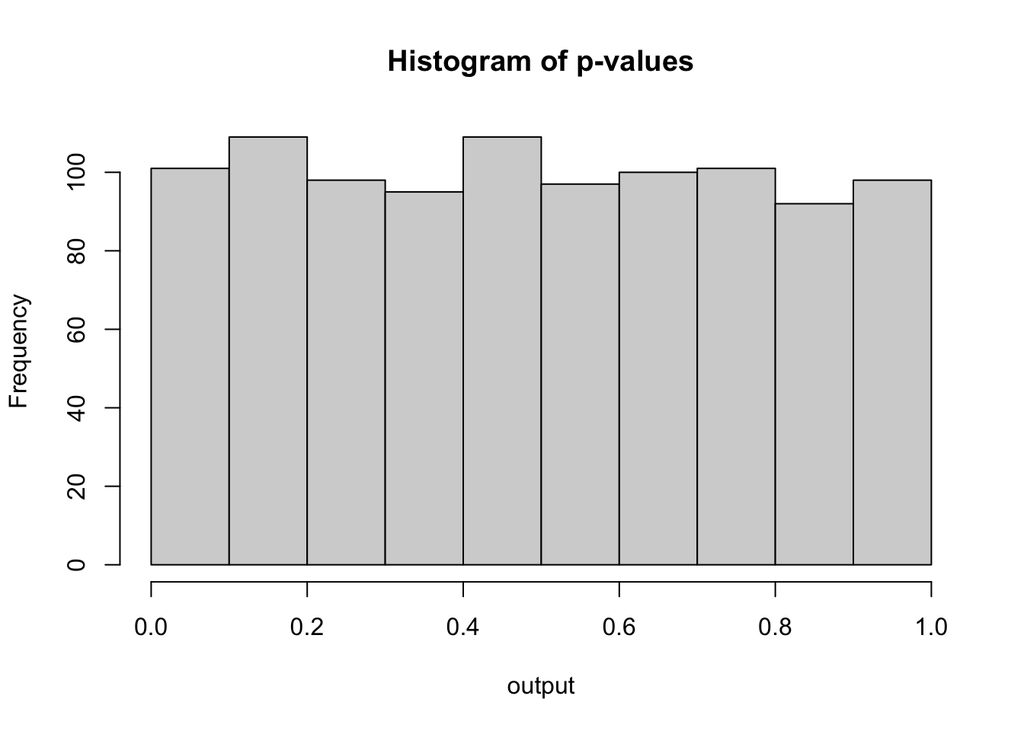

```r
# Regress y on x’s:
# An intercept is needed here, because both y and x's are random numbers drawn from N(0,1).

# Estimated model is: y = a0 + a1*x + e

# obs<-10000                # obs in each single regression (no. of rows in matrix M1)
Nloops<-1000            # number of experiments (no. of columns of x's in matrix M1)
output<-numeric(Nloops) # vector holding p-values of estimated a1 parameter from Nloops experiments

for(i in seq_along(output)){

  x<- M1[,1+i]
  y<- M1[,1]

  # x and y are independent, so null hypothesis is true
  output[i] <-(summary(lm(y~ x)) $ coefficients)[2,4] # we grab p-value of a1

}

plot(hist(output), main="Histogram of p-values")
```

```r
# The histogram looks like a uniform distribution.

# Formal statistical test (optional)
ks.test(output,"punif") # Null hypothesis is that output distr. is uniform
```

```
##
##  Asymptotic one-sample Kolmogorov-Smirnov test
##
## data:  output
## D = 0.019047, p-value = 0.8612
## alternative hypothesis: two-sided
```

# Question 5

```r
# How many "significant" variables to find?
```

1. Since the data was generated in a random way, I expect to find zero “significant” variables out of all 1,000 p-values.
2. If alpha = 0.01, the regression yields 1,000 * 0.01 = 10 “significant” variables.

This tells us that we should not trust the results presented by R, and there is by chance 10 variables that are wrongly shown as significant in terms of 0.01 significant level.

# Question 6

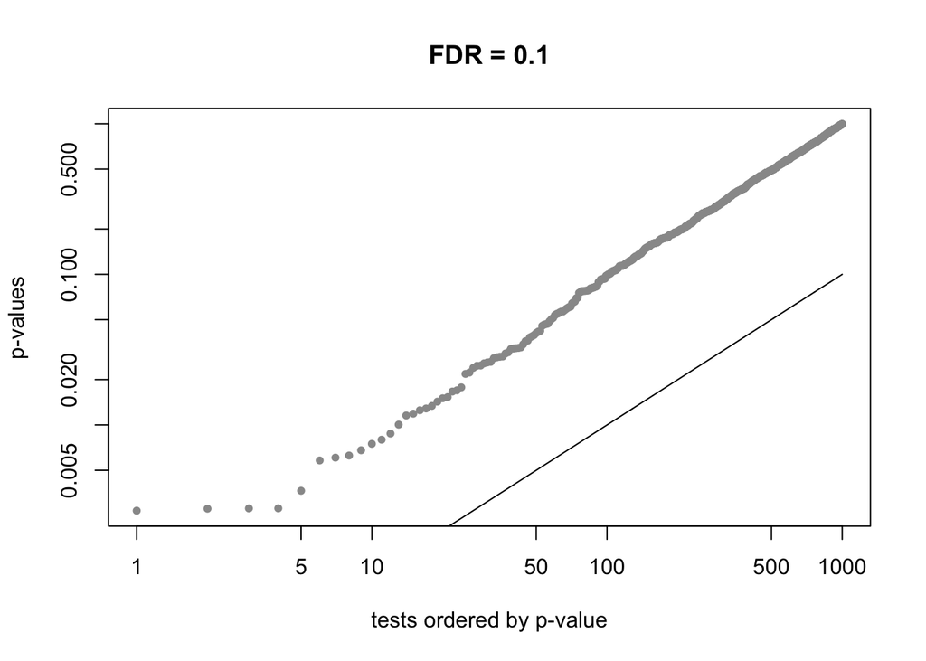

```
## [1] 0
```

```r
# Use the BH procedure to control the FDR with a q of 0.1:
pvals <- output
q <- 0.1

fdr <- function(pvals, q, plotit=TRUE){
      pvals <- pvals[!is.na(pvals)]
      N <- length(pvals)

      k <- rank(pvals, ties.method="min")
      alpha <- max(pvals[ pvals <= (q*k/N) ])

      td <- pvals[ pvals <= alpha ]
      td <- data.frame(td)
      no_td <- nrow(td)

  if(plotit){
    sig <- factor(pvals <= alpha)
    o <- order(pvals)
    plot(pvals[o], log="xy", col=c("grey60","red")[sig[o]], pch=20,
      ylab="p-values", xlab="tests ordered by p-value", main = paste('FDR =',q))
    lines(1:N, q*(1:N) / N)
  }

  return(no_td)
}

fdr(pvals, q)
```

```r
# We estimate zero "true" discoveries, and the plot also confirms that we cannot find the cut-off value in this case.
```

# Question 7

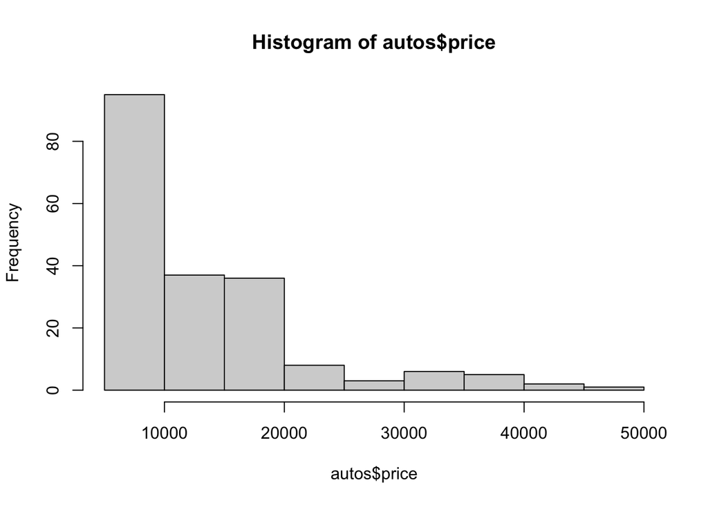

```r
autos <- read.csv("autos.csv")  # View(autos)

# Data Exploration:

hist(autos$price)
```

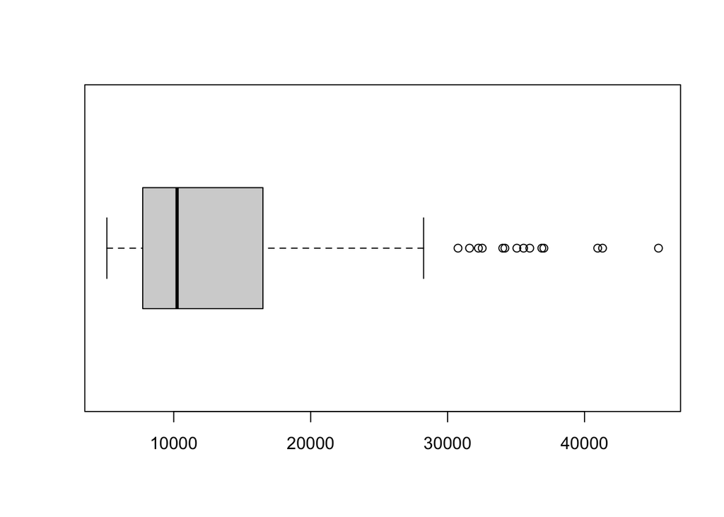

```r
## The histogram shows that the prices of autos are mostly lower than $10,000. The number of autos between price $10,000-15,000 and $15,000-20,000 are approximately the same, while those autos are more expensive than $20,000 take up a minor percentage among all vehicles.

boxplot(autos$price, horizontal = TRUE)
```

```r
## In addition, the boxplot of prices show that outliers with extremely high price are distributed mainly between $30,000 and $40,000.
```

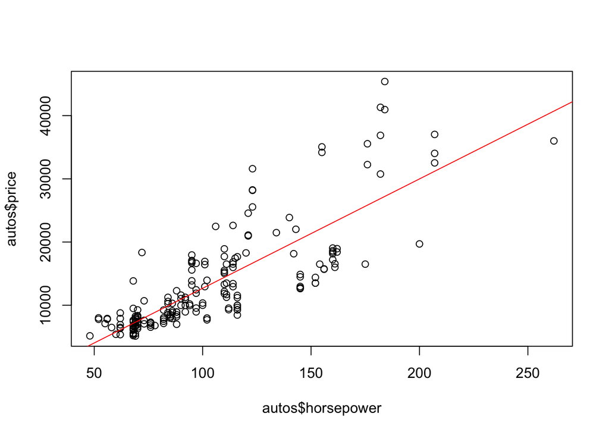

```r
plot(autos$price ~ autos$horsepower)

reg <- lm(autos$price ~ autos$horsepower)
abline(reg, col = "red")
```

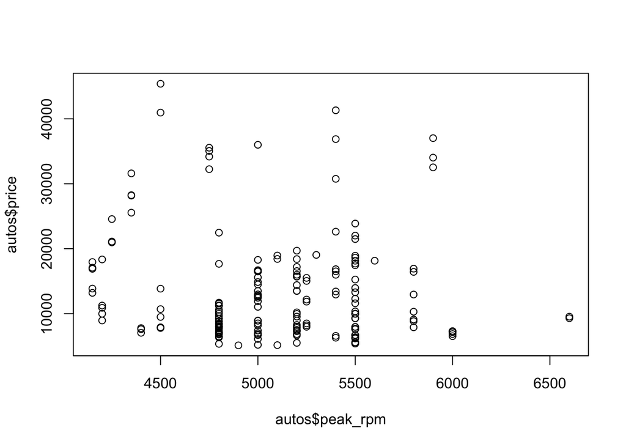

```r
## The first scatterplot shows that as the horsepower of autos increases, the price of auto also increases accordingly.

plot(autos$price ~ autos$peak_rpm)
```

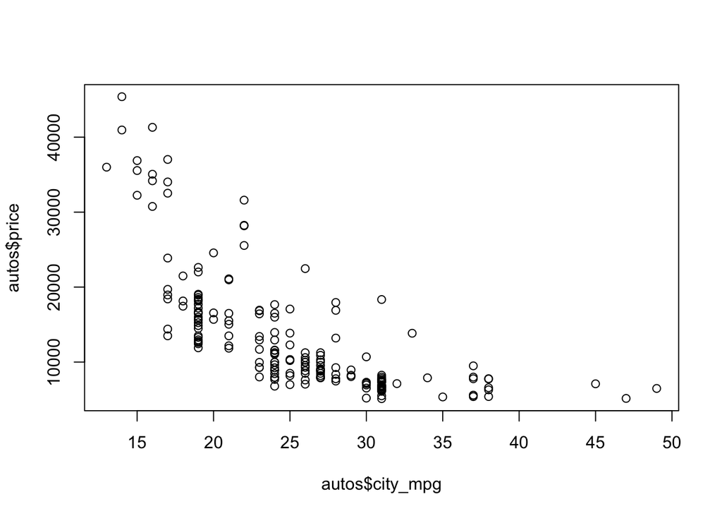

```r
plot(autos$price ~ autos$city_mpg)
```

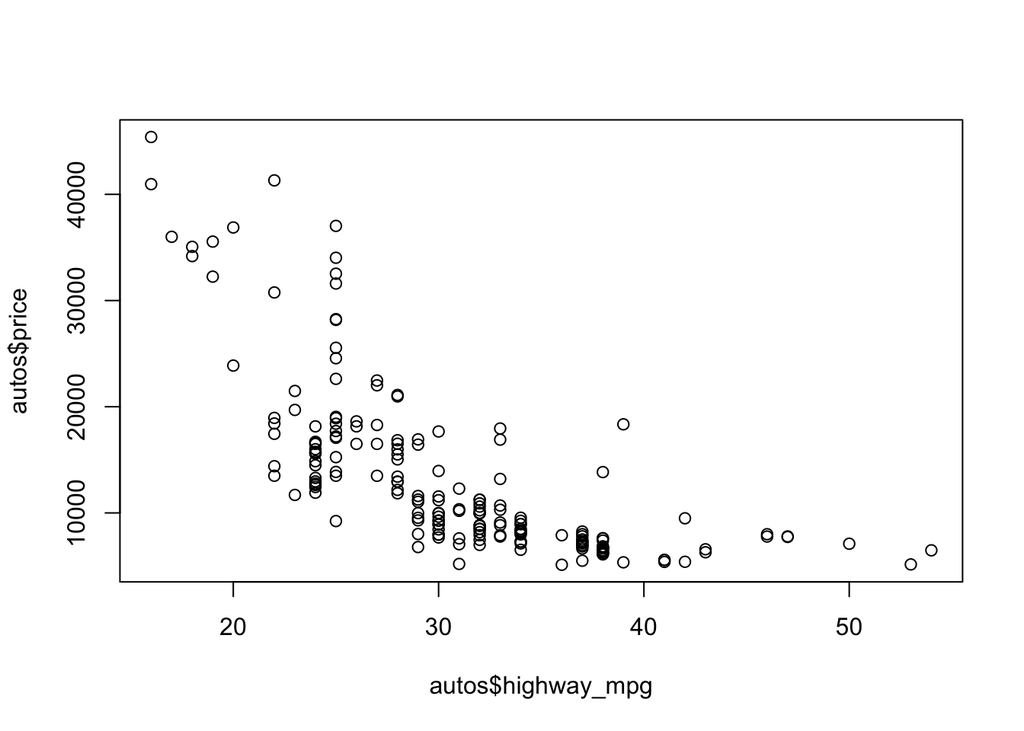

```r
plot(autos$price ~ autos$highway_mpg)
```

```r
## The following three scatterplots show that for different values of peak_rpm, city_mpg, and highway_mpg, the mean and standard variation of auto price vary accordingly among different groups. In general, the higher the city_mpg/highway_mpg is, the lower the price is.
```

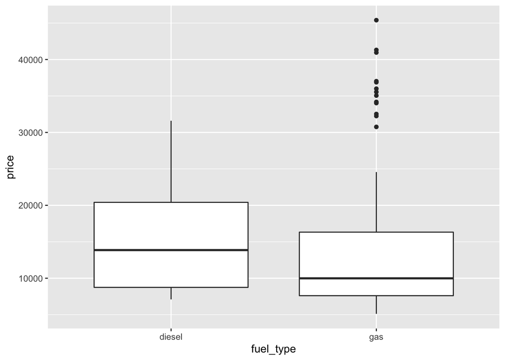

```r
library(ggplot2)

ggplot(data = autos, aes(x= fuel_type, y= price)) + geom_boxplot()
```

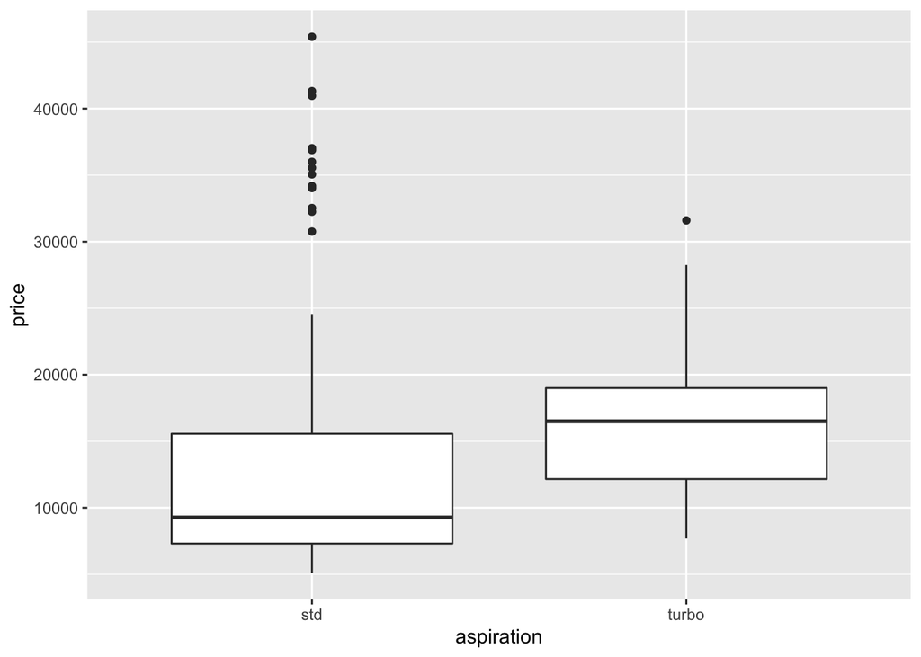

```r
ggplot(data = autos, aes(x= aspiration, y= price)) + geom_boxplot()
```

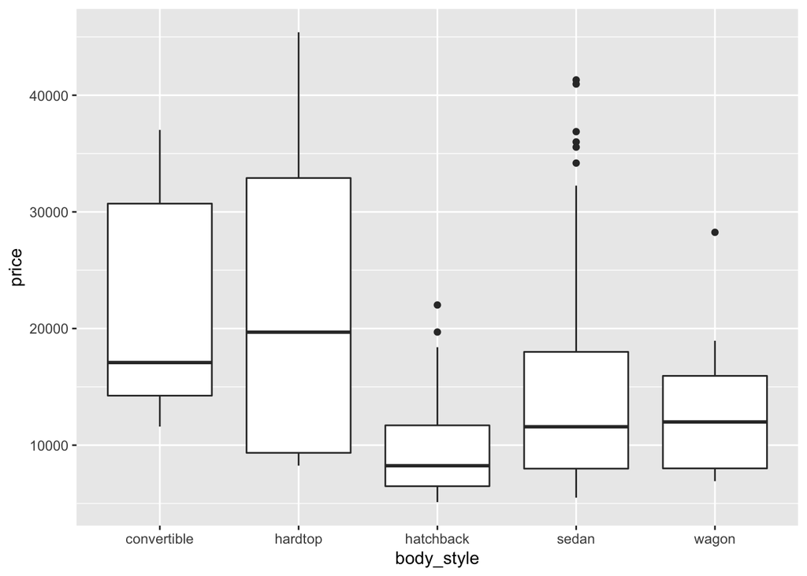

```r
ggplot(data = autos, aes(x= body_style, y= price)) + geom_boxplot()
```

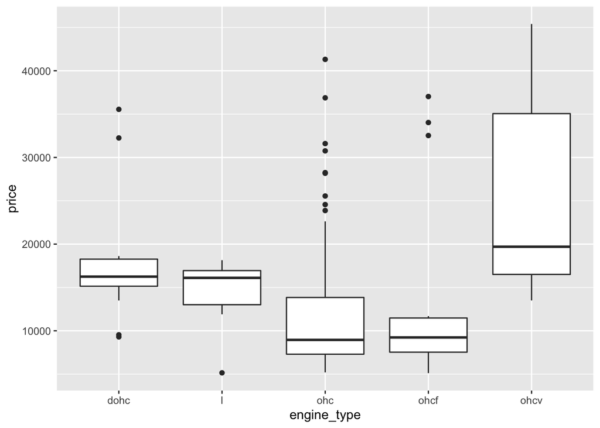

```r
ggplot(data = autos, aes(x= engine_type, y= price)) + geom_boxplot()
```

```r
# These boxplots similarly show that the distribution of price varies in terms of different fuel_type, aspiration, body_style, or engine_type. The four factors play an important role in determining the price of autos to customers.
```

# Question 8

```r
# Create a linear regression model to predict price:

# List of numeric variables
wheel_base <- autos$wheel_base
length <- autos$length
width <- autos$width
height <- autos$height
curb_weight <- autos$curb_weight
num_of_cylinders <- autos$num_of_cylinders
engine_size <- autos$engine_size
bore <- autos$bore
stroke <- autos$stroke
compression_ratio <- autos$compression_ratio
horsepower <- autos$horsepower
peak_rpm <- autos$peak_rpm
city_mpg <- autos$city_mpg
highway_mpg <- autos$highway_mpg

price <- autos$price

# Convert character to numeric value for "num_of_doors" variable
num_of_doors <- ifelse(autos$num_of_doors == 'two', 2, 4)

# Create dummy variables for non-numeric values
gas_dummy <- ifelse(autos$fuel_type == "gas", 1, 0)

std_dummy <- ifelse(autos$aspiration == 'std', 1, 0)

convertible_dummy <- ifelse(autos$body_style == 'convertible', 1, 0)
hardtop_dummy <- ifelse(autos$body_style == 'hardtop', 1, 0)
hatchback_dummy <- ifelse(autos$body_style == 'hatchback', 1, 0)
sedan_dummy <- ifelse(autos$body_style == 'sedan', 1, 0)

fwd_dummy <- ifelse(autos$drive_wheels == 'fwd', 1, 0)
rwd_dummy <- ifelse(autos$drive_wheels == 'rwd', 1, 0)

front_dummy <- ifelse(autos$engine_location == 'front', 1, 0)

dohc_dummy <- ifelse(autos$engine_type == 'dohc', 1, 0)
ohc_dummy <- ifelse(autos$engine_type == 'ohc', 1, 0)
ohcf_dummy <- ifelse(autos$engine_type == 'ohcf', 1, 0)
ohcv_dummy <- ifelse(autos$engine_type == 'ohcv', 1, 0)

lbbl_dummy <- ifelse(autos$fuel_system == '1bbl', 1, 0)
idi_dummy <- ifelse(autos$fuel_system == 'idi', 1, 0)
mfi_dummy <- ifelse(autos$fuel_system == 'mfi', 1, 0)
mpfi_dummy <- ifelse(autos$fuel_system == 'mpfi', 1, 0)
spdi_dummy <- ifelse(autos$fuel_system == 'spdi', 1, 0)
spfi_dummy <- ifelse(autos$fuel_system == 'spfi', 1, 0)
```

```r
### First run a regression model with all variables for a quick check for multicollinearity
LM <- lm(price ~ wheel_base + length + width + height + curb_weight + num_of_cylinders + engine_size + bore + stroke
         + compression_ratio + horsepower + peak_rpm + city_mpg + highway_mpg
         + num_of_doors
         + gas_dummy + std_dummy
         + convertible_dummy + hardtop_dummy + hatchback_dummy + sedan_dummy
         + fwd_dummy + rwd_dummy
         + front_dummy
         + dohc_dummy + ohc_dummy + ohcf_dummy + ohcv_dummy
         + lbbl_dummy + idi_dummy + mfi_dummy + mpfi_dummy + spdi_dummy + spfi_dummy)

## car::vif(LM)
## "Error in vif.default(LM) : there are aliased coefficients in the model".
## Evidence of multicollinearity.
## The error indicates that two or more predictor variables in the model are highly (or perfectly) correlated.
```

```r
### Store all vars + Dummy in a separate dataframe
df_LM <- data.frame(price, wheel_base, length, width, height, curb_weight, num_of_cylinders, engine_size, bore, stroke, compression_ratio, horsepower, peak_rpm, city_mpg, highway_mpg, num_of_doors, gas_dummy, std_dummy, convertible_dummy, hardtop_dummy, hatchback_dummy, sedan_dummy, fwd_dummy, rwd_dummy, front_dummy, dohc_dummy, ohc_dummy, ohcf_dummy, ohcv_dummy, lbbl_dummy, idi_dummy, mfi_dummy, mpfi_dummy + spdi_dummy + spfi_dummy)

### Create correlation matrix for this data frame
cor(df_LM)
```

```
##                                             price  wheel_base       length
## price                                 1.000000000  0.58495062  0.695927914
## wheel_base                            0.584950622  1.00000000  0.879306884
## length                                0.695927914  0.87930688  1.000000000
## width                                 0.754648895  0.81846532  0.857367846
## height                                0.136233814  0.59123908  0.491050293
## curb_weight                           0.835367754  0.78217251  0.882694059
## num_of_cylinders                      0.746006940  0.33944523  0.447884969
## engine_size                           0.888778495  0.56837489  0.686997642
## bore                                  0.546295275  0.49595748  0.606372548
## stroke                                0.096006684  0.17422471  0.121888488
## compression_ratio                     0.074482616  0.25223353  0.156060684
## horsepower                            0.812453205  0.37703974  0.589650163
## peak_rpm                             -0.103835312 -0.35082348 -0.276144452
## city_mpg                             -0.706617993 -0.50449931 -0.702142602
## highway_mpg                          -0.719177688 -0.57177129 -0.731263958
## num_of_doors                          0.046460421  0.44745954  0.400636045
## gas_dummy                            -0.115440219 -0.31019577 -0.209881872
## std_dummy                            -0.186072627 -0.26398792 -0.249014087
## convertible_dummy                     0.191054987 -0.18167521 -0.056748462
## hardtop_dummy                         0.229996830 -0.01436276  0.043625550
## hatchback_dummy                      -0.303807528 -0.39597629 -0.468555302
## sedan_dummy                           0.151263846  0.29923976  0.302786178
## fwd_dummy                            -0.603597700 -0.47998232 -0.528988349
## rwd_dummy                             0.647897380  0.52354766  0.565384789
## front_dummy                          -0.330847533  0.19297200  0.054784794
## dohc_dummy                            0.154188596  0.06333839  0.169093070
## ohc_dummy                            -0.339386768 -0.22468634 -0.294938429
## ohcf_dummy                            0.016319717 -0.19319086 -0.127341937
## ohcv_dummy                            0.393493506  0.16065848  0.243255723
## lbbl_dummy                           -0.174584083 -0.19981304 -0.309020800
## idi_dummy                             0.115440219  0.31019577  0.209881872
## mfi_dummy                            -0.002871562 -0.03556233 -0.006531517
## mpfi_dummy...spdi_dummy...spfi_dummy  0.493668016  0.30191776  0.481974289
##                                            width      height curb_weight
## price                                 0.75464889  0.13623381  0.83536775
## wheel_base                            0.81846532  0.59123908  0.78217251
## length                                0.85736785  0.49105029  0.88269406
## width                                 1.00000000  0.31064047  0.86763966
## height                                0.31064047  1.00000000  0.30583747
```

[output cut: 353 more lines]

```
## convertible_dummy                                              0.17636142
## hardtop_dummy                                                  0.10075484
## hatchback_dummy                                               -0.13238569
## sedan_dummy                                                    0.04741428
## fwd_dummy                                                     -0.41914487
## rwd_dummy                                                      0.45021485
## front_dummy                                                   -0.12371791
## dohc_dummy                                                     0.25351292
## ohc_dummy                                                     -0.27087817
## ohcf_dummy                                                    -0.02386803
## ohcv_dummy                                                     0.26459656
## lbbl_dummy                                                    -0.24969617
## idi_dummy                                                     -0.33562431
## mfi_dummy                                                     -0.07329943
## mpfi_dummy...spdi_dummy...spfi_dummy                           1.00000000
```

```r
## The matrix shows that there is high correlation between variables listed below:

## length/width/curb_weight and wheel_base, width and length/curb_weight/engine_size/highway_mpg, length/width/engine_size/horsepower/city_mpg/highway_mpg and curb_weight, num_of_cylinders and engine_size/horsepower, engine_size and horsepower/city_mpg/highway_mpg, compression_ratio and gas_dummy, horsepower and city_mpg/highway_mpg, city_mpg and highway_mpg, fwd_dummy and rwd_dummy, idi_dummy and compression_ratio, spfi_dummy and city_mpg.

## Therefore, some variables can be removed from the original model, including:
## length, width, curb_weight, horsepower, city_mpg, highway_mpg, num_of_cylinders, gas_dummy,idi_dummy, rwd_dummy, spfi_dummy.

## Also, note that we need to keep/remove all dummy variables related to the same categorical variable (e.g. fuel_type).
## Therefore, the variables that are determined to be removed from the model are:
## length, width, curb_weight, horsepower, city_mpg, highway_mpg, num_of_cylinders,
## gas_dummy,idi_dummy, lbbl_dummy, mfi_dummy, mpfi_dummy, spdi_dummy, spfi_dummy (in terms of fuel_system variable),
## rwd_dummy,fwd_dummy (in terms of drive_wheels variable).
```

```r
# Run a new regression model after removing the above unnecessary variables:
LM2 <- lm(price ~ wheel_base + height + engine_size + bore + stroke
         + compression_ratio + peak_rpm
         + num_of_doors
         + std_dummy
         + convertible_dummy + hardtop_dummy + hatchback_dummy + sedan_dummy
         + front_dummy
         + dohc_dummy + ohc_dummy + ohcf_dummy + ohcv_dummy)

car::vif(LM2)  ### No evidence of multicollinearity for the new model
```

```
##        wheel_base            height       engine_size              bore
##          6.028334          2.769689          7.281347          2.684720
##            stroke compression_ratio          peak_rpm      num_of_doors
##          1.990387          1.684471          1.911670          2.737836
##         std_dummy convertible_dummy     hardtop_dummy   hatchback_dummy
##          1.373417          1.957231          2.167079          5.167913
##       sedan_dummy       front_dummy        dohc_dummy         ohc_dummy
##          3.137177          2.462841          2.811265          5.129694
##        ohcf_dummy        ohcv_dummy
##          3.598139          4.567100
```

```r
### Run Forward Selection
library(olsrr, warn.conflicts = FALSE)
```

```r
fwd <- ols_step_forward_p(LM2, penter = 0.10, details = TRUE)
```

```r
fwd
```

```
##
##                                    Selection Summary
## ---------------------------------------------------------------------------------------
##         Variable                           Adj.
## Step         Entered         R-Square    R-Square      C(p)         AIC         RMSE
## ---------------------------------------------------------------------------------------
##    1    engine_size            0.7899      0.7888    183.3688    3724.9020    3717.2187
##    2    front_dummy            0.8145      0.8125    141.8737    3702.9293    3502.5627
##    3    wheel_base             0.8431      0.8406     93.1253    3672.5821    3229.5162
##    4    convertible_dummy      0.8525      0.8494     78.4463    3662.6464    3139.4998
##    5    peak_rpm               0.8612      0.8575     65.0245    3652.9124    3053.6307
##    6    std_dummy              0.8675      0.8633     55.8150    3645.9122    2991.2628
##    7    stroke                 0.8734      0.8686     47.3986    3639.1551    2932.0569
##    8    ohc_dummy              0.8888      0.8839     22.1569    3616.1763    2755.7846
##    9    bore                   0.8918      0.8865     18.7942    3612.8539    2725.4636
##   10    ohcv_dummy             0.8963      0.8906     12.7991    3606.6361    2675.3722
##   11    sedan_dummy            0.8987      0.8926     10.5056    3604.0740    2651.2325
## ---------------------------------------------------------------------------------------
```

```r
### Run Backward Elimination
bwd <- ols_step_backward_p(LM2, prem = 0.10, details = TRUE)
```

```r
bwd
```

```
##
##
##                                  Elimination Summary
## --------------------------------------------------------------------------------------
##         Variable                           Adj.
## Step         Removed         R-Square    R-Square     C(p)         AIC         RMSE
## --------------------------------------------------------------------------------------
##    1    dohc_dummy             0.9018      0.8923    17.0011    3610.0632    2654.6373
##    2    num_of_doors           0.9018      0.8929    15.0075    3608.0703    2647.1334
##    3    ohcf_dummy             0.9016      0.8933    13.3796    3606.4825    2642.4656
##    4    hardtop_dummy          0.9012      0.8935    12.0938    3605.2713    2640.4231
##    5    hatchback_dummy        0.9007      0.8935    11.0419    3604.3136    2640.1566
##    6    compression_ratio       0.900      0.8933    10.2870    3603.6738    2642.1067
##    7    height                 0.8987      0.8926    10.5056    3604.0740    2651.2325
## --------------------------------------------------------------------------------------
```

```r
### Run Stepwise Regression
stepwise <- olsrr::ols_step_both_p(LM2, prem = 0.05, pent = 0.05, details = TRUE)
```

```r
stepwise
```

```
##
##                                     Stepwise Selection Summary
## ---------------------------------------------------------------------------------------------------
##                               Added/                   Adj.
## Step        Variable         Removed     R-Square    R-Square      C(p)         AIC         RMSE
## ---------------------------------------------------------------------------------------------------
##    1       engine_size       addition       0.790       0.789    183.3690    3724.9020    3717.2187
##    2       front_dummy       addition       0.814       0.813    141.8740    3702.9293    3502.5627
##    3       wheel_base        addition       0.843       0.841     93.1250    3672.5821    3229.5162
##    4    convertible_dummy    addition       0.853       0.849     78.4460    3662.6464    3139.4998
##    5        peak_rpm         addition       0.861       0.857     65.0240    3652.9124    3053.6307
##    6        std_dummy        addition       0.868       0.863     55.8150    3645.9122    2991.2628
##    7         stroke          addition       0.873       0.869     47.3990    3639.1551    2932.0569
##    8        ohc_dummy        addition       0.889       0.884     22.1570    3616.1763    2755.7846
##    9          bore           addition       0.892       0.886     18.7940    3612.8539    2725.4636
##   10       ohcv_dummy        addition       0.896       0.891     12.7990    3606.6361    2675.3722
##   11       sedan_dummy       addition       0.899       0.893     10.5060    3604.0740    2651.2325
## ---------------------------------------------------------------------------------------------------
```

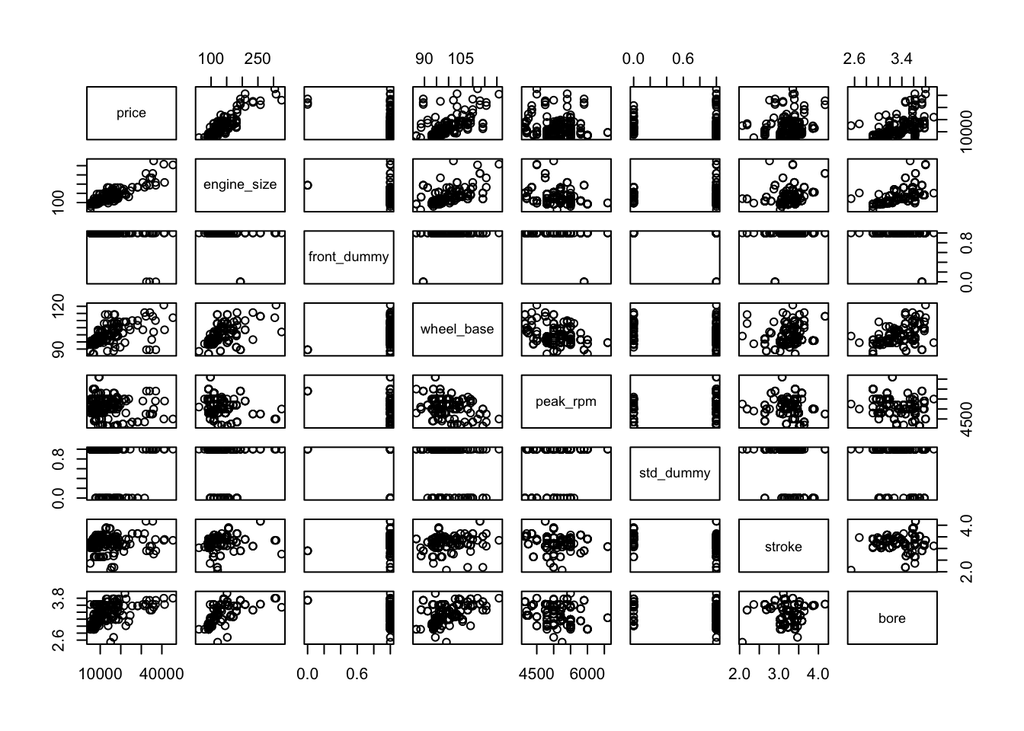

```r
### Consider selected variables only and create a separate data frame
df_sel_var <- data.frame(price, engine_size, front_dummy, wheel_base, convertible_dummy, peak_rpm, std_dummy, stroke, ohc_dummy, bore, ohcv_dummy, sedan_dummy)

## Exclude dummy variables that are associated with already-removed dummy variables (of the same categorical variable in autos dataset)
df_sel_var_final <- data.frame(price, engine_size, front_dummy, wheel_base, peak_rpm, std_dummy, stroke, bore)

### Quickly create a scatterplot to see if there is any evidence of nonlinearity.
plot(df_sel_var_final)
```

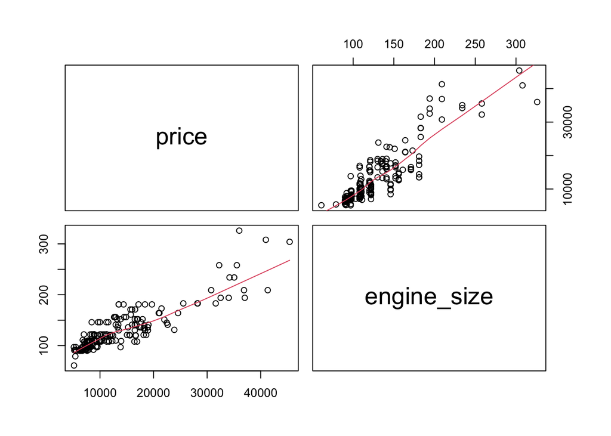

```r
### OR
pairs(df_sel_var_final[1:2], panel = panel.smooth)
```

```r
## Final Model (with 7 variables including 2 dummies)
final_LM <- lm(price ~ engine_size + front_dummy + wheel_base + peak_rpm + std_dummy + stroke + bore)

# Avoid scientific notation in R output
options(scipen = 100, digits = 4)

# Summary of model output
summary(final_LM)
```

```
##
## Call:
## lm(formula = price ~ engine_size + front_dummy + wheel_base +
##     peak_rpm + std_dummy + stroke + bore)
##
## Residuals:
##    Min     1Q Median     3Q    Max
##  -8863  -1477   -343   1076  15326
##
## Coefficients:
##               Estimate Std. Error t value             Pr(>|t|)
## (Intercept) -14166.588   7001.154   -2.02              0.04446 *
## engine_size    154.226      7.683   20.07 < 0.0000000000000002 ***
## front_dummy -13223.996   2032.740   -6.51         0.0000000007 ***
## wheel_base     312.322     49.730    6.28         0.0000000024 ***
## peak_rpm         1.750      0.511    3.42              0.00076 ***
## std_dummy    -2389.925    615.806   -3.88              0.00014 ***
## stroke       -2872.928    763.886   -3.76              0.00023 ***
## bore         -2347.913   1103.597   -2.13              0.03470 *
## ---
## Signif. codes:  0 '***' 0.001 '**' 0.01 '*' 0.05 '.' 0.1 ' ' 1
##
## Residual standard error: 3000 on 185 degrees of freedom
## Multiple R-squared:  0.868,  Adjusted R-squared:  0.863
## F-statistic:  173 on 7 and 185 DF,  p-value: <0.0000000000000002
```

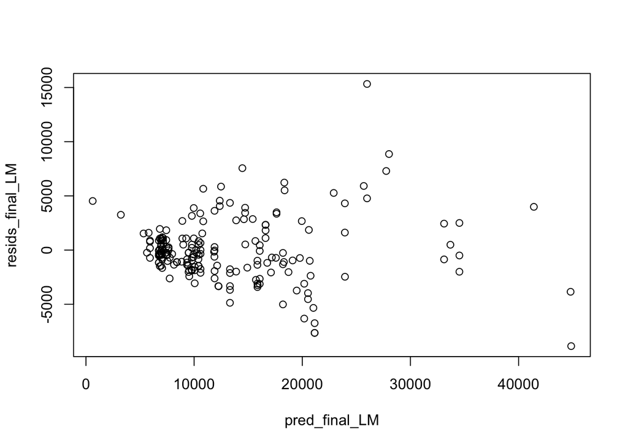

```r
### Regression diagnostics...
resids_final_LM <- residuals(final_LM)
pred_final_LM <- predict(final_LM)

plot(pred_final_LM, resids_final_LM)
```

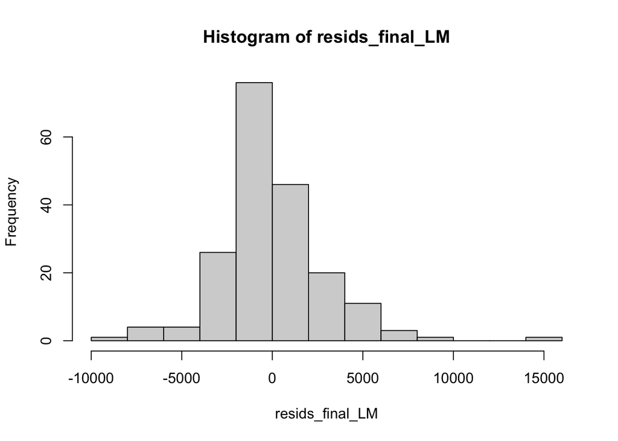

```r
hist(resids_final_LM)
```

Therefore, the linear regression model is:

price = -14166.588 + 154.226*engine_size -13223.996*front_dummy + 312.322*wheel_base + 1.750*peak_rpm -2389.925*std_dummy -2872.928*stroke -2347.913*bore.

Interpretations:

For every one unit increase in engine size, the price of autos increases by approximately $154.226. Other variables that are not dummy variables can also be explained in similar ways.

In addition, the dummy variables in the model show that if the engine location is not in the front/the aspiration is not std, the price of autos tends to be higher, and vice versa.

# Question 9

False discoveries can be an issue because if coefficients that are not significant are wrongly considered as significant, the result of our prediction model will be inaccurate and not reliable. Including variables that have little influence on determining prices might lead to overestimate/underestimate of the actual price. We can no longer rely on any inference based on that.

# Question 10

```r
# Use the BH procedure to control the FDR with a q of 0.1
q <- 0.1

# Obtain p-values from the above regression model
pvals <- summary(final_LM)$coeff[2:8,4]

# Show p-values (optional)
as.vector(pvals)
```

```
## [1] 0.000000000000000000000000000000000000000000000002481
## [2] 0.000000000703576185731223451205899778736511593346670
## [3] 0.000000002350411519785157725525059403421518355870035
## [4] 0.000762428851031136185951997408238867137697525322437
## [5] 0.000144593979111667844108732317032206537987804040313
## [6] 0.000226980030065894081798757997425752819253830239177
## [7] 0.034702167707994044376640374593989690765738487243652
```

```r
## Extract p-value cutoff for E[fdp] < q (optional in this question), which is denoted as p*
fdr <- function(pvals, q, plotit=FALSE){
  pvals <- pvals[!is.na(pvals)]
  N <- length(pvals)

  k <- rank(pvals, ties.method="min")
  alpha <- max(pvals[ pvals <= (q*k/N) ])

  if(plotit){
    sig <- factor(pvals <= alpha)
    o <- order(pvals)
    plot(pvals[o], log="xy", col=c("grey60","red")[sig[o]], pch=20,
      ylab="p-values", xlab="tests ordered by p-value", main = paste('FDR =',q))
    lines(1:N, q*(1:N) / N)
  }

  return(alpha)
}

# Show the p-value cutoff result (optional)
fdr(pvals,q)
```

```
## [1] 0.0347
```

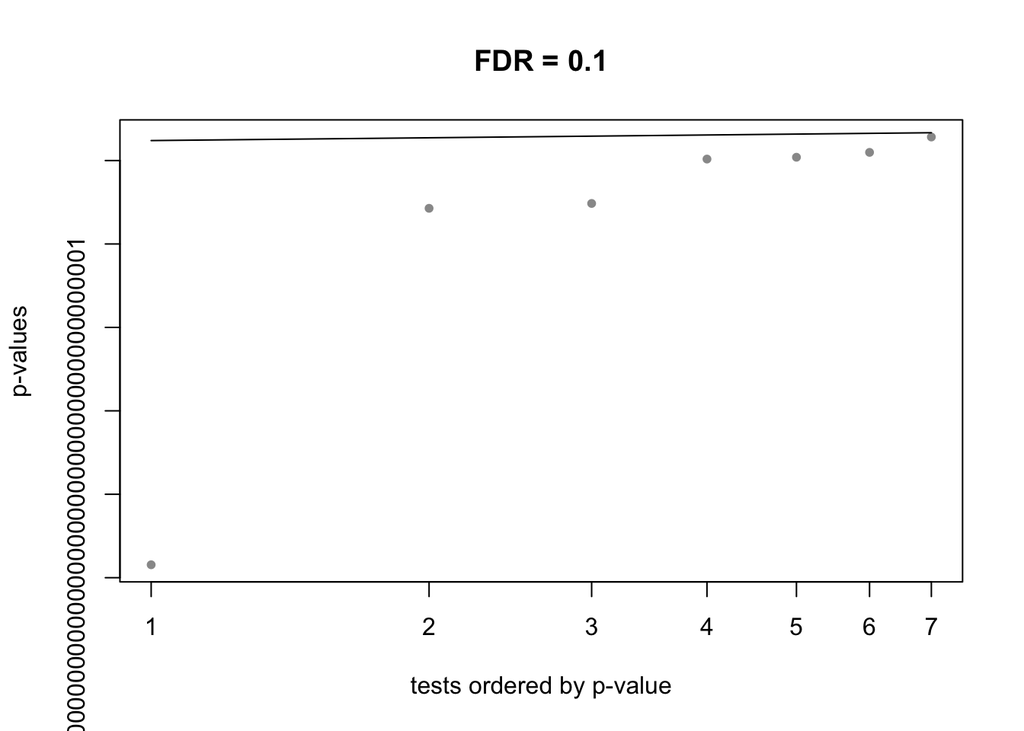

```
## [1] 7
```

```r
# Define a function called td()
# Set the output of td as the number of true discoveries (the number of p-values <= p*)

td <- function(pvals, q, plotit=TRUE){
  pvals <- pvals[!is.na(pvals)]
  N <- length(pvals)
  k <- rank(pvals, ties.method="min")
  alpha <- round(max(pvals[ pvals <= (q*k/N) ]), digits = 9)

  td <- pvals[ pvals <= alpha ]
  td <- data.frame(td)
  no_td <- nrow(td)

    if(plotit){
    sig <- factor(pvals <= alpha)
    o <- order(pvals)
    plot(pvals[o], log="xy", col=c("grey60","red")[sig[o]], pch=20,
      ylab="p-values", xlab="tests ordered by p-value", main = paste('FDR =',q))
    lines(1:N, q*(1:N) / N)
  }

  return(no_td)
}

# Show output of the function when q=0.1
# Also, plot the cutoff line together with the significant and insignificant p-values
td(pvals,q)
```

```r
## We estimate there are 7 true discoveries in the final regression model.
```